# Bar Charts and Histograms

As always, let’s begin by importing our necessary packages and reading in/previewing our data. In this practice we will continue to explore the `titanic` dataset.

```python
# import seaborn
import seaborn as sns
# set up for inline plotting
%matplotlib inline
```

```python
# read in titanic data
titanic = sns.load_dataset("titanic")
# preview data
titanic.head()
```

|  | survived | pclass | sex | age | sibsp | parch | fare | embarked | class | who | adult_male | deck | embark_town | alive | alone |
| --- | --- | --- | --- | --- | --- | --- | --- | --- | --- | --- | --- | --- | --- | --- | --- |
| 0 | 0 | 3 | male | 22.0 | 1 | 0 | 7.2500 | S | Third | man | True | NaN | Southampton | no | False |
| 1 | 1 | 1 | female | 38.0 | 1 | 0 | 71.2833 | C | First | woman | False | C | Cherbourg | yes | False |
| 2 | 1 | 3 | female | 26.0 | 0 | 0 | 7.9250 | S | Third | woman | False | NaN | Southampton | yes | True |
| 3 | 1 | 1 | female | 35.0 | 1 | 0 | 53.1000 | S | First | woman | False | C | Southampton | yes | False |
| 4 | 0 | 3 | male | 35.0 | 0 | 0 | 8.0500 | S | Third | man | True | NaN | Southampton | no | True |

## Bar Charts

Generate a barplot of `survived` (y-axis) across `sex` (x-axis).

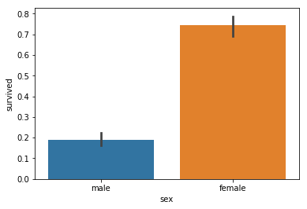

```python
# barplot of sex vs survived
sns.barplot(x="sex", y = 'survived', data=titanic)
```

Now, generate a barplot of `survived` (y-axis) across `sex` (x-axis), stratified by `class`. Choose your favorite color palette.

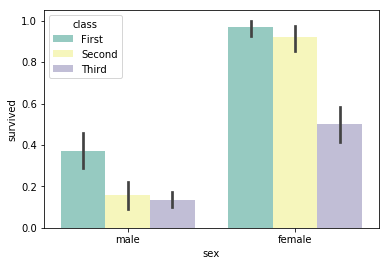

```python
# barplot of sex vs survived stratified by class
sns.barplot(x="sex", y = 'survived', hue = "class", palette = "Set3",data=titanic)
```

## Histograms

Generate a histogram of `fare`

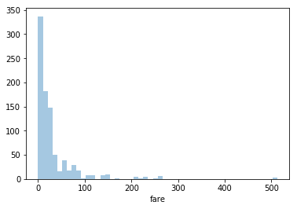

```python
#histogram of fare
sns.distplot(titanic['fare'], kde=False)
```

Now let’s play with the `bins` parameter. First let’s try a small number of bins, like 10:

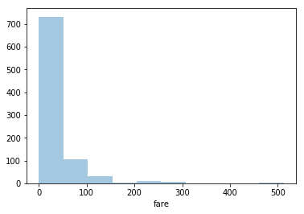

```python
#histogram of fare with 10 bins
sns.distplot(titanic['fare'], kde=False, bins=10)
```

Now, let’s try a larger number of bins, say 100.

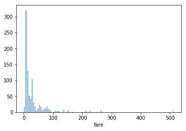

```python
#histogram of fare with 100 bins
sns.distplot(titanic['fare'], kde=False, bins=100)
```

As you can see, most of the values are pretty small (< 100 dollars), and there are only a few really large values. This is called a long-tailed distribution. Can you plot a histogram of just the fares that are less than 100 dollars?

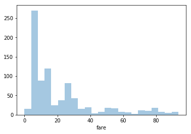

```python
#histogram of fare
sns.distplot(titanic.query('fare < 100')['fare'], kde=False)
```

## Count Plots

Generate a count plot to visualize the distribution the `deck` variable across all passengers in our data set. Choose a sequential color palette.

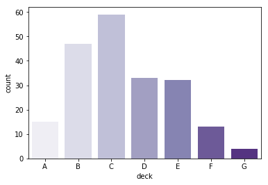

```python
# count plot of deck
sns.countplot(x="deck", palette = "Purples", data=titanic)
```

Now stratify your plot using the `class` variable. What kind of color palette is appropriate now?

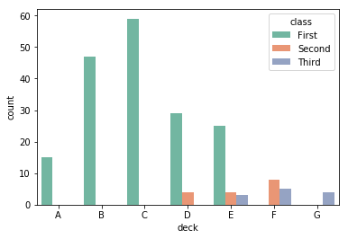

```python
# count plot of deck stratified by class
sns.countplot(x="deck", hue = "class", palette = "Set2", data=titanic)
```

## Congratulations!

You just completed all of the core lessons in the GWC Club! Now it’s time to keep putting your data science skills to the test in your projects.